# Eindopdracht Assesment Daur2 door Mariana Mousa & Khadija Zbair

2024-04-10

## Introductie: Onderzoek naar Transdifferentiatie van Fibroblasten naar Hersencellen

Neurologische aandoeningen worden vaak veroorzaakt door disfunctionele zenuwstelsel. Om deze soorten ziektes te onderzoeken wordt Transdifferentiatie techniek gebruikt. Transdifferentiatie is een andere mogelijke benadering voor het genereren van therapeutische cellen. Hierbij worden somatische cellen(in dit onderzek fibroblasten) van de patient zelf geisoleerd en kunnen worden getransdifferentieerd naar stamcellen die de mogelijkheid hebben om weer te differentieeren naar hersencellen door de juiste transcriptiefactoren toe te voegen . Deze herprogrammeringsmethode biedt een aantrekkelijke aanpak voor regeneratieve geneeskunde. In dit al gepubliceerde onderzoek is een deel van de fibroblasten van één proefpersoon behandeld met een controle transcriptiefactor (BCLXL), terwijl een ander deel is behandeld met een transcriptiefactor (ONECUT3) waarvan wordt vermoed dat het fibroblasten kan omzetten naar hersencellen.

De onderzoeksvraag is: “Hoe verandert de gen expressie in de cellen die met BCLXL transcriptiefactor behandeld vs cellen behandeld met ONECUT3 transcriptiefactor?”

Eigenschappen van de dataset: * De RNA-seq datasets bestaan uit paired reads. * Voor het genereren van de datasets is gebruik gemaakt van een stranded protocol (de reads kunnen dus gebruikt worden om te bepalen of de RNA moleculen afkomstig waren van de plus of min strand).

Dit R Markdown bestand zal dienen als basis voor de analyse en visualisatie van deze data om antwoorden te vinden op deze onderzoeksvraag.

## Kwaliteitscontrole van de FASTQ-bestanden

Voordat we doorgaan met de analyse van de RNA-seq-gegevens, is het noodzakelijk om de kwaliteit van de FASTQ-bestanden te beoordelen.

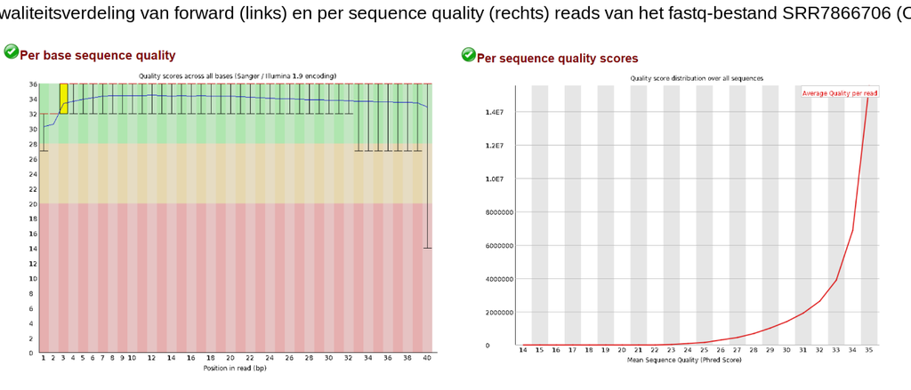

Figuur 1: De forward read van SRR7866706 (ONCECUT3).De rechter figur is de per sequence quality score, hier is een piek aan de rechterkant, dus de meeste reads gemiddeld een hoge Phred score hebben. De linker figuur is de forward read. De Phred-scores (y-as) uitgezet die loopt van 0 tot 40 voor elke base van de sequentie-uitlezingen (x-as). De meeste basen hebben een gemiddelde Phred score van >30 (aangegeven met de blauwe lijn), wat betekent dat de kans op een fout in de basecall 1 op 1000 is. Dit komt overeen met een nauwkeurigheid van 99,9%.

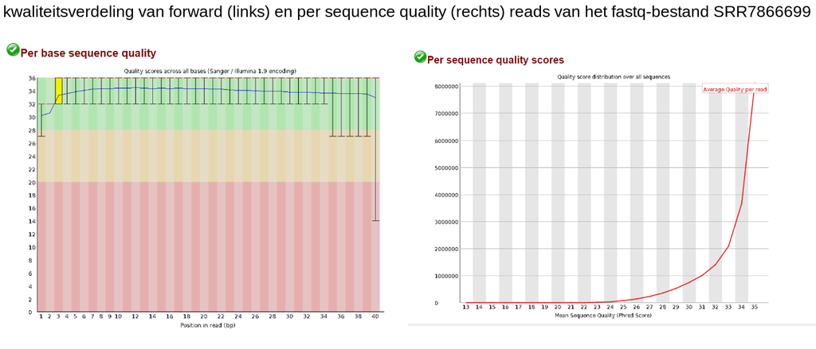

Figuur 1: De forward read van SRR7866699 (BCLXL). De rechter figuur is de per sequence quality score, hier is een piek aan de rechterkant, dus de meeste reads gemiddeld een hoge Phred score hebben. De linker figuur is de forward read. De Phred-scores (y-as) zijn uitgezet die loopt van 0 tot 40 voor elke base van de sequentie-uitlezingen (x-as). De meeste basen hebben een gemiddelde Phred score van >30 (aangegeven met de blauwe lijn), wat betekent dat de kans op een fout in de basecall 1 op 1000 is. Dit komt overeen met een nauwkeurigheid van 99,9%.

Over het algemeen is de kwaliteit van de FastQ-bestanden goed. Dit geldt zowel voor de kwaliteit per basissequentie als voor de kwaliteitsscores per sequentie. We kunnen de fastq-bestanden dus gebruiken voor stroomafwaartse analyses.

## Count table

Een tellingstabel voor RNA-seq geeft het aantal gealigneerde fragmenten weer per gen in het menselijk genoom voor elk monster.

```r
# Een object met de input directory naar de bamfiles
onecut_bam_inputdir <- "/home/daur2/rnaseq/rnaseq_onecut/bam/"

# Een object met de output directory
onecut_counts_outputdir <- "~/daur2/rnaseq_onecut/"

# Een vector met de namen van de bam files
bam_files_onecut <- list.files(onecut_bam_inputdir, pattern = "^SRR7866(699|700|705|706).*\\.bam$", full.names = TRUE)

# Tel de reads per gen met de in-built NCBI RefSeq annotaties.
onecut_counts_table <-

  featureCounts(
  files = bam_files_onecut,
  annot.inbuilt = "hg38", #Menselijke genoom (hg38)
  useMetaFeatures = TRUE,
  strandSpecific = 1, #Stranded protocol gebruikt
  isPairedEnd = TRUE, #De RNA-seq datasets bestaan uit paired reads
  countReadPairs = TRUE,
  nthreads = 10,
  reportReadsPath = onecut_counts_outputdir)
```

## Maken van een DESeq2 object met de count table en csv bestand

Nu we een count table hebben voor het RNA-seq-dataset, kunnen we beginnen met statistische analyses in R met behulp van het DESeq2-pakket, een veelgebruikt pakket voor differentiële expressie-analyses.

We moeten onze count table omzetten naar een DESeq-object.

```r
# Inlezen van de count table
count_table <- read_rds('/home/daur2/rnaseq/rnaseq_onecut/counts/read_counts_OC3.rds')
head(count_table)

# Maken van een count matrix door de kolom 'counts' te nemen van de count table
count_matrix <- count_table$counts
head(count_matrix)

# Importeren van de meta data
onecut_metadata <- read_csv('/home/daur2/rnaseq/rnaseq_onecut/onecut_sampledata_OC3.csv')

# Converteer de metadata naar het dataframe-object
onecut_metadata_df <- as.data.frame(onecut_metadata)

# Voeg rownames toe aan de zojuist gemaakte metadata dataframe
head(onecut_metadata_df)
rownames(onecut_metadata_df) <- paste0(onecut_metadata_df$Run, ".bam")

# Controleer of de kolomnamen van de count matrix overeenkomen met de rijnamen van de metadata dataframe
colnames(count_matrix) == rownames(onecut_metadata_df)

# Kolom toevoegen waarin iedere test conditie werd opgedeeld in ONECUT3 en BCLXL vervolgens werden deze met de factor zo ingesteld dat de BCLXL als baseline worden gebruikt en de ONECUT3 data wordt hiermee vergeleken.

onecut_metadata_df <- onecut_metadata_df %>% mutate(transcription_factor = str_replace(Cell_type, "Skin derived fibroblast overexpressing Bclxl", "BCLXL")) %>% mutate(transcription_factor = str_replace(transcription_factor, "2 days after induction of OC3 in skin derived fibroblasts", "ONECUT3"))

onecut_metadata_df$transcription_factor <- onecut_metadata_df$transcription_factor %>% factor(levels = c("BCLXL", "ONECUT3"))

#DESeq object maken
onecut_dds <- DESeqDataSetFromMatrix(
  countData = count_matrix,
  colData = onecut_metadata_df,
  design = ~ transcription_factor
)
```

## PCA-analyse

In het hersenonderzoek zijn diverse RNA-seq-monsters verzameld. We willen begrijpen hoe deze monsters zich tot elkaar verhouden en of behandelingen de monsters beïnvloeden. Het vergelijken van genexpressiewaarden van zoveel genen voor elk monster is echter onpraktisch. Daarom gebruiken we dimensionale reductiemethoden zoals PCA. Hierbij worden lineaire combinaties van genen gemaakt om nieuwe variabelen te vormen, die de monsters op een samenvattende manier beschrijven.

```
##                             PC1      PC2      PC3         PC4
## Standard deviation     37.25778 7.955918 6.823376 2.63093e-13
## Proportion of Variance  0.92667 0.042250 0.031080 0.00000e+00
## Cumulative Proportion   0.92667 0.968920 1.000000 1.00000e+00
```

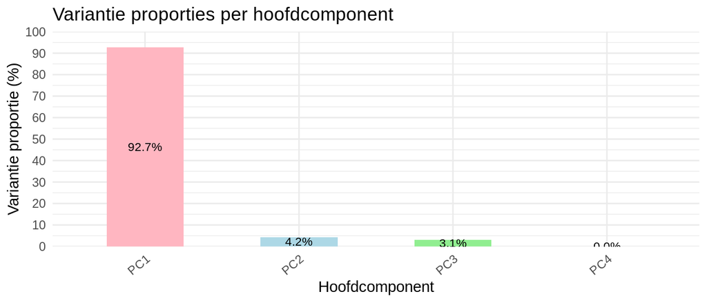

```
##                       Run Assay Type AvgSpotLen      Bases  BioProject
## SRR7866699.bam SRR7866699    RNA-Seq         86 1594016622 PRJNA491516
## SRR7866700.bam SRR7866700    RNA-Seq         86 4004919208 PRJNA491516
## SRR7866705.bam SRR7866705    RNA-Seq         86 1668581718 PRJNA491516
## SRR7866706.bam SRR7866706    RNA-Seq         86 3024999432 PRJNA491516
##                   BioSample      Bytes                     Cell_line
## SRR7866699.bam SAMN10079869  662419376 Fibroblast line 1 (CL1500023)
## SRR7866700.bam SAMN10079867 1664172935 Fibroblast line 1 (CL1500023)
## SRR7866705.bam SAMN10079860  694097838 Fibroblast line 1 (CL1500023)
## SRR7866706.bam SAMN10079858 1256058351 Fibroblast line 1 (CL1500023)
##                                                                Cell_type
## SRR7866699.bam              Skin derived fibroblast overexpressing Bclxl
## SRR7866700.bam              Skin derived fibroblast overexpressing Bclxl
## SRR7866705.bam 2 days after induction of OC3 in skin derived fibroblasts
## SRR7866706.bam 2 days after induction of OC3 in skin derived fibroblasts
##                Center Name Consent DATASTORE filetype DATASTORE provider
## SRR7866699.bam         GEO  public          fastq,sra         gs,ncbi,s3
## SRR7866700.bam         GEO  public          fastq,sra         gs,ncbi,s3
## SRR7866705.bam         GEO  public          fastq,sra         gs,ncbi,s3
## SRR7866706.bam         GEO  public          fastq,sra         gs,ncbi,s3
##                              DATASTORE region Experiment GEO_Accession (exp)
## SRR7866699.bam gs.US,ncbi.public,s3.us-east-1 SRX4705879          GSM3393013
## SRR7866700.bam gs.US,ncbi.public,s3.us-east-1 SRX4705880          GSM3393014
## SRR7866705.bam gs.US,ncbi.public,s3.us-east-1 SRX4705885          GSM3393019
## SRR7866706.bam gs.US,ncbi.public,s3.us-east-1 SRX4705886          GSM3393020
##                 Instrument LibraryLayout LibrarySelection  LibrarySource
## SRR7866699.bam NextSeq 500        PAIRED             cDNA TRANSCRIPTOMIC
## SRR7866700.bam NextSeq 500        PAIRED             cDNA TRANSCRIPTOMIC
## SRR7866705.bam NextSeq 500        PAIRED             cDNA TRANSCRIPTOMIC
## SRR7866706.bam NextSeq 500        PAIRED             cDNA TRANSCRIPTOMIC
##                    Organism Platform ReleaseDate Sample Name       source_name
## SRR7866699.bam Homo sapiens ILLUMINA  2019-04-05  GSM3393013 Fibroblast line 1
## SRR7866700.bam Homo sapiens ILLUMINA  2019-04-05  GSM3393014 Fibroblast line 1
## SRR7866705.bam Homo sapiens ILLUMINA  2019-04-05  GSM3393019 Fibroblast line 1
## SRR7866706.bam Homo sapiens ILLUMINA  2019-04-05  GSM3393020 Fibroblast line 1
##                SRA Study transcription_factor       PC1        PC2        PC3
## SRR7866699.bam SRP161949                BCLXL -31.67082  9.7946502 -0.7405102
## SRR7866700.bam SRP161949                BCLXL -32.83919 -9.6414752  0.4585311
## SRR7866705.bam SRP161949              ONECUT3  33.30445 -0.7783505 -8.1919880
## SRR7866706.bam SRP161949              ONECUT3  31.20556  0.6251756  8.4739671
##                          PC4
## SRR7866699.bam -3.952688e-13
## SRR7866700.bam -1.490651e-13
## SRR7866705.bam  3.392989e-13
## SRR7866706.bam  2.520805e-13
```

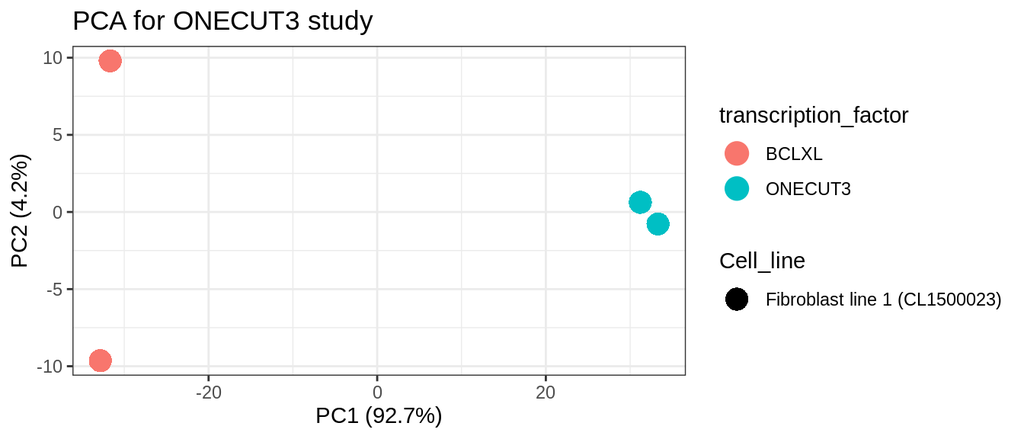

Op basis van de PC2 kunnen we zeggen dat de monsters die met ONECUT3 zijn behandeld samen clusteren, wat betekent dat deze vergelijkbare eigenschappen vertonen. De monsters die met BCLXL zijn behandeld, clusteren niet samen met elkaar. Mogelijk komt dit omdat BCLXL bij een deel van de monsters tot overexpressie is gekomen en bij een deel niet, waardoor je verschil hebt in anatomische en fysische eigenschappen en daarmee twee verschillende celtypen overhoud (de een is misschien al bijna geheel hersencel en de ander deel fibroblast en deel hersencel).

## DGE analyse met behulp van DESeq2

```r
# Voer een DGE-analyse uit met de DESeq2 object
onecut_dge <- DESeq(onecut_dds)

# De resultaten van de DGE-analyse samenvatten
results_onecut_dge <- results(onecut_dge ,lfcThreshold = 1, alpha = 0.01)
summary(results_onecut_dge)
```

```
##
## out of 21139 with nonzero total read count
## adjusted p-value < 0.01
## LFC > 1.00 (up)    : 661, 3.1%
## LFC < -1.00 (down) : 644, 3%
## outliers [1]       : 0, 0%
## low counts [2]     : 6439, 30%
## (mean count < 6)
## [1] see 'cooksCutoff' argument of ?results
## [2] see 'independentFiltering' argument of ?results
```

De samenvatting van de differentiële genexpressie-analyse toont het volgende:

- 661 genen (3,1%) zijn significant upgereguleerd (LFC > 1). 644 genen (3%) zijn significant downgereguleerd (LFC < -1).
- Er zijn geen uitbijters gevonden.
- Ongeveer 30% van de genen vertonen lage leeswaarden (gemiddeld < 6), wat belangrijk is om mee te nemen in verdere analyses.

## Count plot

```r
# Obtain the genes with a significant p-value
sign_genes <- results_onecut_dge[which(results_onecut_dge$padj < 0.05),]

# Obtain the id of the most significantly upregulated gene
upGene <- sign_genes[which.max(sign_genes$log2FoldChange),]
upGene_name <- rownames(upGene)
upGene_name
```

```
## [1] "390874"
```

```r
# Obtain the id of the most significantly downregulated gene
downGene <- sign_genes[which.min(sign_genes$log2FoldChange),]
downGene_name <- rownames(downGene)
downGene_name
```

```
## [1] "8707"
```

## Volcano plot met up- en downgereguleerde genen

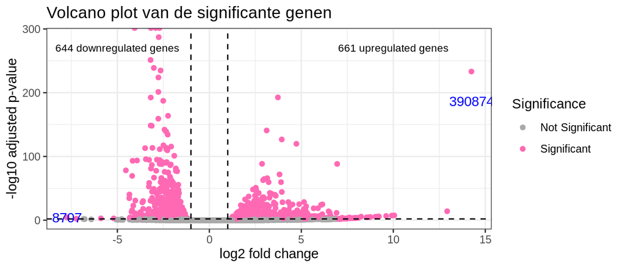

Figuur 4: De downgereguleerde genen links en upgereguleerde genen rechts.

Conclusie volcano plot: In deze volcano plot zijn de genen onderscheiden met een significantie van 0,01. De meest upgereguleerde genen bevinden zich aan de rechterkant van de LFC stippellijn. De meest downgereguleerde genen bevinden zich aan de linkerkant van de stippelijn. Het gen met ID 390874 is het meest upgereguleerd, het gen met ID 8707 is het meest downgereguleerd. Er zijn in totaal 644 downgereguleerde genen en 661 upgereguleerde genen.

## 2e Volcano plot met achtergrond

```r
results_onecut_dge1 <- results(onecut_dge)
summary(results_onecut_dge1)
```

```
##
## out of 21139 with nonzero total read count
## adjusted p-value < 0.1
## LFC > 0 (up)       : 4650, 22%
## LFC < 0 (down)     : 4300, 20%
## outliers [1]       : 0, 0%
## low counts [2]     : 3613, 17%
## (mean count < 1)
## [1] see 'cooksCutoff' argument of ?results
## [2] see 'independentFiltering' argument of ?results
```

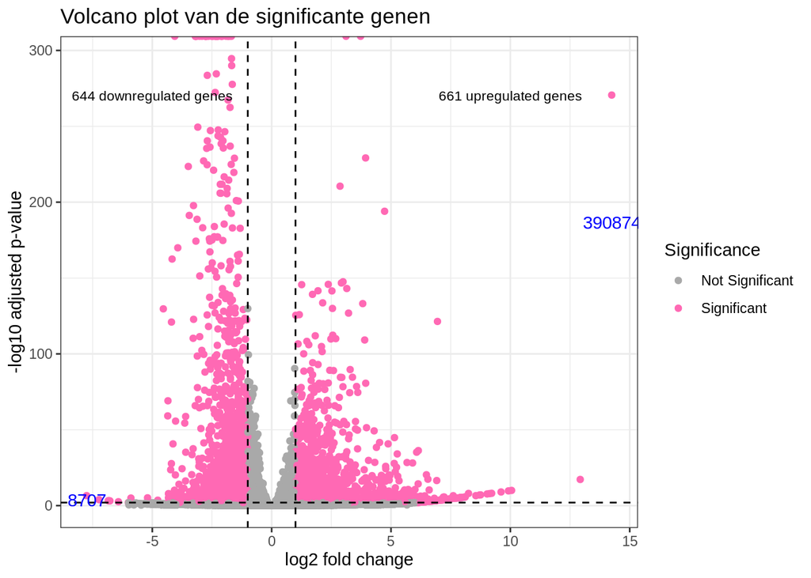

```r
# Maak een dataframe voor plotten zonder genen met padj = NA
onecut_volcano_plot1 <- data.frame(results_onecut_dge1) %>% filter(!is.na(padj))

# Maak een kolom die specificeert of het gen significant differentieel tot expressie wordt gebracht
onecut_volcano_plot1 <- onecut_volcano_plot1 %>%
  mutate(signif = if_else(padj < 0.01 & abs(log2FoldChange)  >1 , "Significant", "Not Significant"))

upregulated <- nrow(filter(onecut_volcano_plot, padj < 0.01 & log2FoldChange  > 1))
downregulated <- nrow(filter(onecut_volcano_plot, padj < 0.01 & log2FoldChange  <  -1))

# Maak een volcano plot
onecut_volcano_plot1 %>%
  ggplot(aes(x = log2FoldChange, y = -log10(padj), color = signif)) +
  geom_point() +
  labs(title = "Volcano plot van de significante genen") +
  xlab("log2 fold change") +
  ylab("-log10 adjusted p-value") +
  theme_bw() + scale_colour_manual(values = c("darkgrey", "hotpink"), name = "Significance")+
  geom_hline(yintercept = -log10(0.01), linetype = "dashed")+
  geom_vline(xintercept =  1, linetype = "dashed")+
   geom_vline(xintercept =  -1, linetype = "dashed")+
   annotate("text", x = 10, y = 270, size=3,
           label = paste(upregulated , "upregulated genes")) +
  annotate("text", x = -5, y = 270, size=3,
           label = paste(downregulated , "downregulated genes"))+
    annotate("text", x = upGene$log2FoldChange, y = -log10(upGene$padj)*0.8,
           label = upGene_name, colour = "blue")+
    annotate("text", x = downGene$log2FoldChange, y = -log10(downGene$padj)*0.8,
           label = downGene_name, colour = "blue")
```

## Heatmap met de count values voor de 5 meest upgereguleerde genen en de 5 meest downgereguleerde genen.

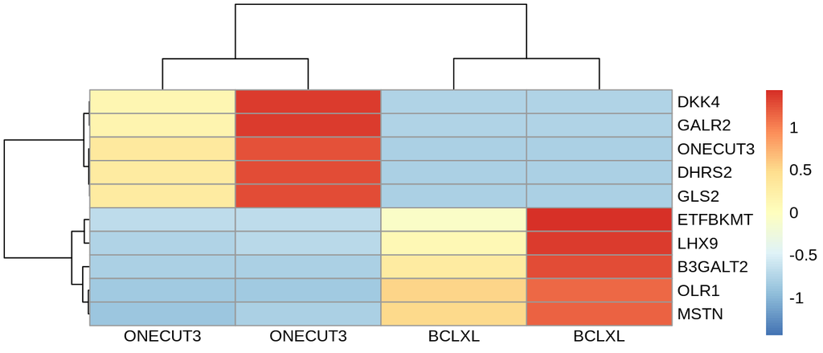

Figuur 5: De heatmap die de 5 meest upgereguleerde en downgereguleerde genen laat zien.

## Functionele annotatie: Genensymbolen ophalen voor een gegeven GO-term

```r
#Functie definiëren
GOidToSymbol <- function(GO_term) {
  genen <- mapIds(org.Hs.eg.db,
                  keys = GO_term,
                  column = "SYMBOL",
                  keytype = "GO",
                  multiVals = "list")

# Extraheren van de genensymbolen en omzetten naar een character vector
genen_symbols <- unlist(genen)

# Geef de genensymbolen terug als een character vector
return(as.character(genen_symbols))
}

#Run the function
GOidToSymbol(GO_term= "GO:0016597")
```

```
##  [1] "AARS1" "AGXT"  "ASS1"  "CASR"  "DDC"   "DPYS"  "GCHFR" "GOT2"  "KARS1"
## [10] "OTC"   "TAT"   "TDO2"  "TH"    "DDAH2" "DDAH1" "SCLY"  "AARS2"
```

## GO term enrichment analyse

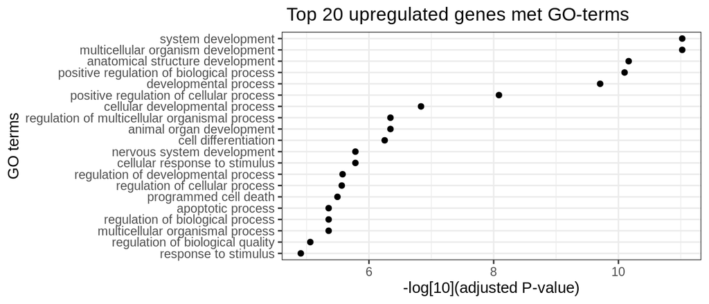

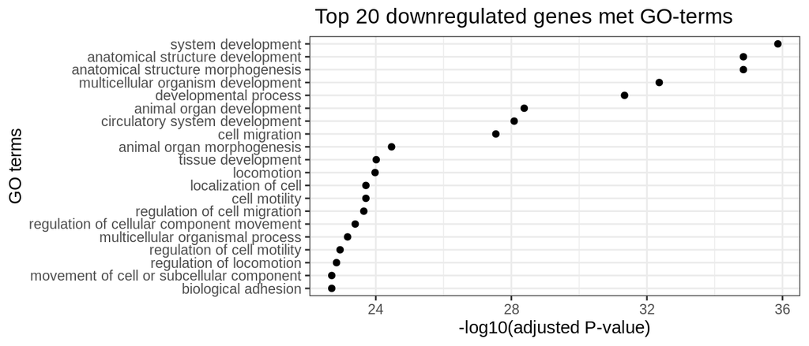

## Eindconclusie

Op basis van de bovenstaande resultaten kan er geconludeerd worden dat de transcriptiefactor ONECUT3 sterk wordt geasocieerd met de differentiatie van fibroblasten naar neurale cellen. Uit de GO-term enrichment analyse is gebleken dat de upgereguleerde genen een toegenomen ontwikkeling van het zenuwstelselontwikkeling (nervous system development), ook processen voor de anatomische structuur van de cellen zijn actief en een respons op externe stimuli. Ook zien we dat cell differentiatie een GO-term is die wordt geassocieerd met de upgereguleerde genen. Deze bevindingen wijzen op een mogelijke omzetting van fibroblasten naar neurale cellen. Een van de 20 upgereguleerde genen was betrokken bij apoptische processen, mogelijk komt dit door de (over)expressie van ONECUT3.

In het vervolg kunnen er meerdere proefpersonen worden meegenomen en meerdere concentraties van ONECUT3 transcriptiefactor. Ook een negatieve controle, zoals fibroblast zonder transcriptiefactor behandeld.